# EDA_Questions_3

# 28 -- SPK_CASH_RGSTR_NBR Unique identifier for this cash register in this sales outlet.

```
First few rows of Cash Register Number:
0    45
1     8
2    12
3    23
4    11
Name: SPK_CASH_RGSTR_NBR, dtype: int64
```

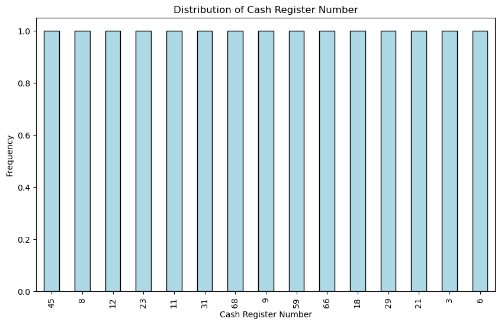

```python
import pandas as pd
import matplotlib.pyplot as plt

# Load the dataset into a Pandas DataFrame
# Assuming the dataset is already loaded and stored in a variable called 'df'
# If not, you can load it using pd.read_csv() or pd.read_excel(), depending on the file format

# Assuming 'SPK_CASH_RGSTR_NBR' is the column of interest
cash_register_number = df['SPK_CASH_RGSTR_NBR']

# Display the first few rows of the column
print("First few rows of Cash Register Number:")
print(cash_register_number.head())

# Get unique values and their counts
unique_values_counts = cash_register_number.value_counts()

# Plot a bar chart to visualize the distribution of values
plt.figure(figsize=(10, 6))
unique_values_counts.plot(kind='bar', color='lightblue', edgecolor='black')
plt.title('Distribution of Cash Register Number')
plt.xlabel('Cash Register Number')
plt.ylabel('Frequency')
plt.grid(False)
plt.show()
```

# 29 -- SPK_POSS_TRAN_CD A code that uniquely identifies a Point of Sale Transaction

```
First few rows of Point of Sale Transaction Code:
0    X6U532ENQSWO6
1    XGGAC19NQT3AM
2    XAT911DNQT4N9
3    XS0191ONQTBD2
4    XNEB91CNQT5LF
Name: SPK_POSS_TRAN_CD, dtype: object
```

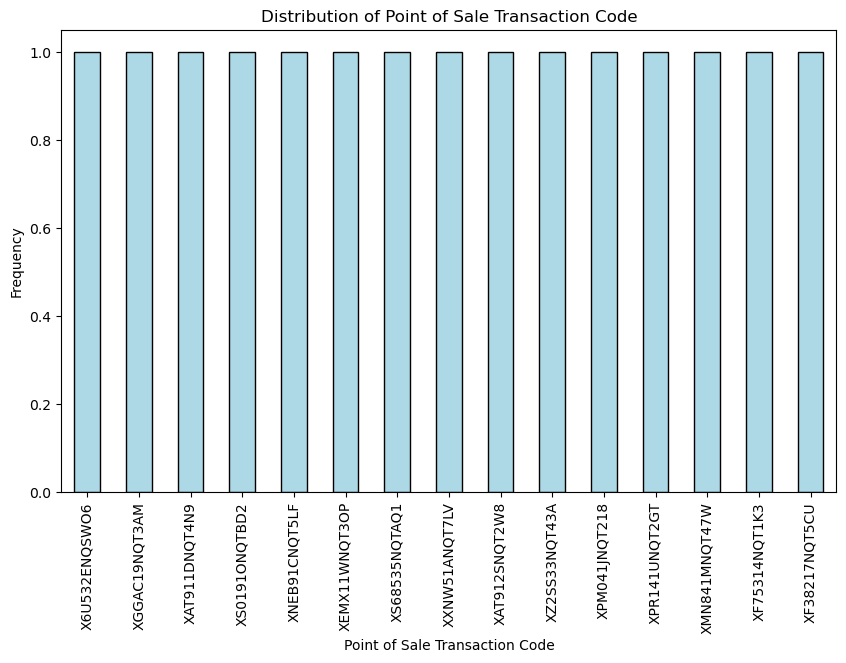

```python
import pandas as pd
import matplotlib.pyplot as plt

# Load the dataset into a Pandas DataFrame
# Assuming the dataset is already loaded and stored in a variable called 'df'
# If not, you can load it using pd.read_csv() or pd.read_excel(), depending on the file format

# Assuming 'SPK_POSS_TRAN_CD' is the column of interest
pos_transaction_code = df['SPK_POSS_TRAN_CD']

# Display the first few rows of the column
print("First few rows of Point of Sale Transaction Code:")
print(pos_transaction_code.head())

# Get unique values and their counts
unique_values_counts = pos_transaction_code.value_counts()

# Plot a bar chart to visualize the distribution of values
plt.figure(figsize=(10, 6))
unique_values_counts.plot(kind='bar', color='lightblue', edgecolor='black')
plt.title('Distribution of Point of Sale Transaction Code')
plt.xlabel('Point of Sale Transaction Code')
plt.ylabel('Frequency')
plt.grid(False)
plt.show()
```

# 30 -- SPK_POSS_USR_CD The unique identifier for this party agent as assigned by the point of sale system.

```
First few rows of Point of Sale User Code:
0    cw241g
1    th7494
2    jv791x
3    hf3622
4    kg860r
Name: SPK_POSS_USR_CD, dtype: object
```

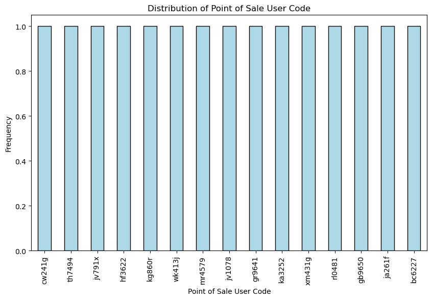

```python
import pandas as pd
import matplotlib.pyplot as plt

# Load the dataset into a Pandas DataFrame
# Assuming the dataset is already loaded and stored in a variable called 'df'
# If not, you can load it using pd.read_csv() or pd.read_excel(), depending on the file format

# Assuming 'SPK_POSS_USR_CD' is the column of interest
pos_user_code = df['SPK_POSS_USR_CD']

# Display the first few rows of the column
print("First few rows of Point of Sale User Code:")
print(pos_user_code.head())

# Get unique values and their counts
unique_values_counts = pos_user_code.value_counts()

# Plot a bar chart to visualize the distribution of values
plt.figure(figsize=(10, 6))
unique_values_counts.plot(kind='bar', color='lightblue', edgecolor='black')
plt.title('Distribution of Point of Sale User Code')
plt.xlabel('Point of Sale User Code')
plt.ylabel('Frequency')
plt.grid(False)
plt.show()
```

# 31 -- SPK_SLS_OTLT_NBR A unique identifier for this sales outlet as assigned by OPUS.

```
First few rows of Sales Outlet Number:
0    6U53
1    GGAC
2    AT91
3    S019
4    NEB9
Name: SPK_SLS_OTLT_NBR, dtype: object
```

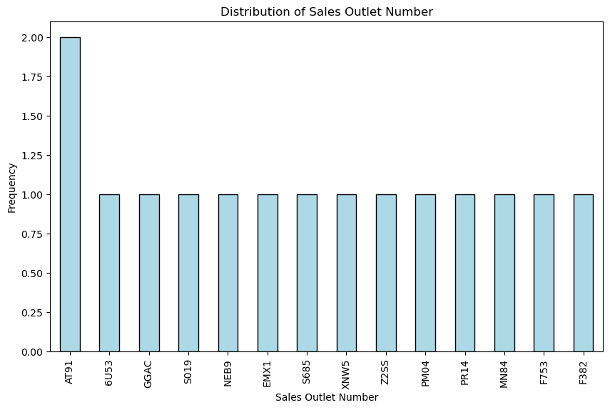

```python
import pandas as pd
import matplotlib.pyplot as plt

# Load the dataset into a Pandas DataFrame
# Assuming the dataset is already loaded and stored in a variable called 'df'
# If not, you can load it using pd.read_csv() or pd.read_excel(), depending on the file format

# Assuming 'SPK_SLS_OTLT_NBR' is the column of interest
sales_outlet_number = df['SPK_SLS_OTLT_NBR']

# Display the first few rows of the column
print("First few rows of Sales Outlet Number:")
print(sales_outlet_number.head())

# Get unique values and their counts
unique_values_counts = sales_outlet_number.value_counts()

# Plot a bar chart to visualize the distribution of values
plt.figure(figsize=(10, 6))
unique_values_counts.plot(kind='bar', color='lightblue', edgecolor='black')
plt.title('Distribution of Sales Outlet Number')
plt.xlabel('Sales Outlet Number')
plt.ylabel('Frequency')
plt.grid(False)
plt.show()
```

# 32 -- TRANS_END_DT_TM This column will have value for trasn end date time

```
First few rows of Transaction End Date and Time:
0    2024-04-01T18:59:10.000+0000
1    2024-04-01T19:22:01.000+0000
2    2024-04-01T19:39:15.000+0000
3    2024-04-01T21:28:42.000+0000
4    2024-04-01T20:06:38.000+0000
Name: TRANS_END_DT_TM, dtype: object
```

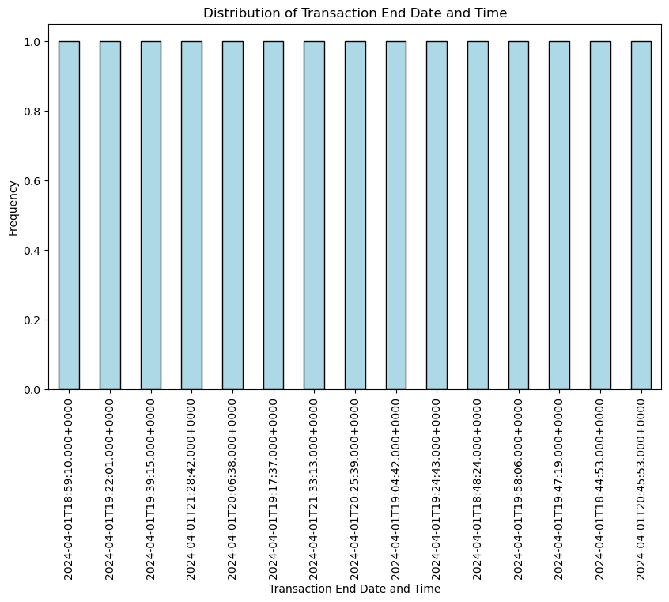

```python
import pandas as pd
import matplotlib.pyplot as plt

# Load the dataset into a Pandas DataFrame
# Assuming the dataset is already loaded and stored in a variable called 'df'
# If not, you can load it using pd.read_csv() or pd.read_excel(), depending on the file format

# Assuming 'TRANS_END_DT_TM' is the column of interest
transaction_end_datetime = df['TRANS_END_DT_TM']

# Display the first few rows of the column
print("First few rows of Transaction End Date and Time:")
print(transaction_end_datetime.head())

# Get unique values and their counts
unique_values_counts = transaction_end_datetime.value_counts()

# Plot a bar chart to visualize the distribution of values
plt.figure(figsize=(10, 6))
unique_values_counts.plot(kind='bar', color='lightblue', edgecolor='black')
plt.title('Distribution of Transaction End Date and Time')
plt.xlabel('Transaction End Date and Time')
plt.ylabel('Frequency')
plt.grid(False)
plt.show()
```

# 33 -- TRANS_ID_TXT Transaction ID assigned by the Vendor API.

```
First few rows of Transaction ID:
0    Mdqce4qiAv9q_z1U
1              #NAME?
2                 NaN
3    NY7R8Jrcg1XG3mhV
4                 NaN
Name: TRANS_ID_TXT, dtype: object
```

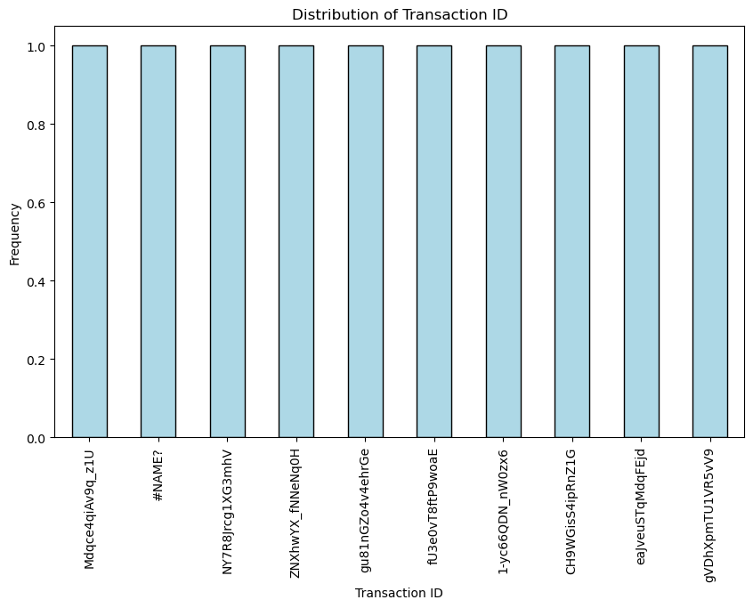

```python
import pandas as pd
import matplotlib.pyplot as plt

# Load the dataset into a Pandas DataFrame
# Assuming the dataset is already loaded and stored in a variable called 'df'
# If not, you can load it using pd.read_csv() or pd.read_excel(), depending on the file format

# Assuming 'TRANS_ID_TXT' is the column of interest
transaction_id = df['TRANS_ID_TXT']

# Display the first few rows of the column
print("First few rows of Transaction ID:")
print(transaction_id.head())

# Get unique values and their counts
unique_values_counts = transaction_id.value_counts()

# Plot a bar chart to visualize the distribution of values
plt.figure(figsize=(10, 6))
unique_values_counts.plot(kind='bar', color='lightblue', edgecolor='black')
plt.title('Distribution of Transaction ID')
plt.xlabel('Transaction ID')
plt.ylabel('Frequency')
plt.grid(False)
plt.show()
```

# 34 --- TRANS_START_DT_TM THis column holds the timestamp on which the opus transactions are made.

```
First few rows of Transaction Start Date and Time:
0    2024-04-01T18:59:10.000+0000
1    2024-04-01T19:21:57.000+0000
2    2024-04-01T19:39:15.000+0000
3    2024-04-01T21:28:42.000+0000
4    2024-04-01T20:06:38.000+0000
Name: TRANS_START_DT_TM, dtype: object
```

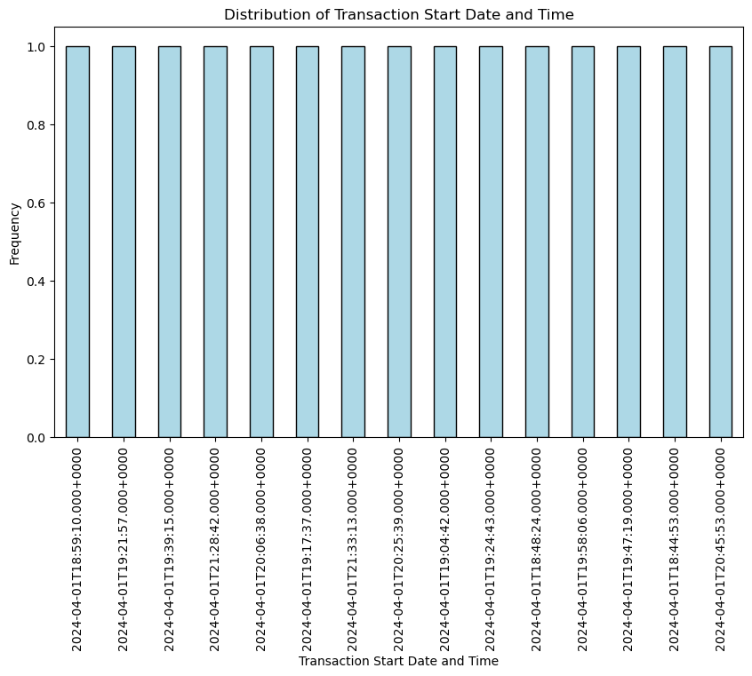

```python
import pandas as pd
import matplotlib.pyplot as plt

# Load the dataset into a Pandas DataFrame
# Assuming the dataset is already loaded and stored in a variable called 'df'
# If not, you can load it using pd.read_csv() or pd.read_excel(), depending on the file format

# Assuming 'TRANS_START_DT_TM' is the column of interest
transaction_start_datetime = df['TRANS_START_DT_TM']

# Display the first few rows of the column
print("First few rows of Transaction Start Date and Time:")
print(transaction_start_datetime.head())

# Get unique values and their counts
unique_values_counts = transaction_start_datetime.value_counts()

# Plot a bar chart to visualize the distribution of values
plt.figure(figsize=(10, 6))
unique_values_counts.plot(kind='bar', color='lightblue', edgecolor='black')
plt.title('Distribution of Transaction Start Date and Time')
plt.xlabel('Transaction Start Date and Time')
plt.ylabel('Frequency')
plt.grid(False)
plt.show()
```

# 35 -- UPDT_DT_TM The date and time the table row was updated.

```
First few rows of Update Date and Time:
0    2024-04-30T02:48:47.000+0000
1    2024-04-30T02:48:47.000+0000
2    2024-04-30T02:48:47.000+0000
3    2024-04-30T02:48:47.000+0000
4    2024-04-30T02:48:47.000+0000
Name: UPDT_DT_TM, dtype: object
```

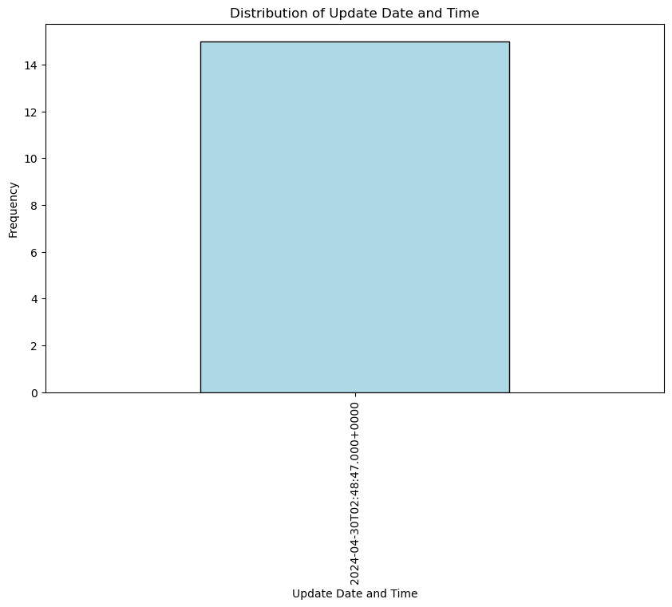

```python
import pandas as pd
import matplotlib.pyplot as plt

# Load the dataset into a Pandas DataFrame
# Assuming the dataset is already loaded and stored in a variable called 'df'
# If not, you can load it using pd.read_csv() or pd.read_excel(), depending on the file format

# Assuming 'UPDT_DT_TM' is the column of interest
update_datetime = df['UPDT_DT_TM']

# Display the first few rows of the column
print("First few rows of Update Date and Time:")
print(update_datetime.head())

# Get unique values and their counts
unique_values_counts = update_datetime.value_counts()

# Plot a bar chart to visualize the distribution of values
plt.figure(figsize=(10, 6))
unique_values_counts.plot(kind='bar', color='lightblue', edgecolor='black')
plt.title('Distribution of Update Date and Time')
plt.xlabel('Update Date and Time')
plt.ylabel('Frequency')
plt.grid(False)
plt.show()
```